# 【Part 2】Project 1 Boston Airbnb new

## Part 2 of the Project

```python
import os
import numpy as np
import pandas as pd
import xgboost as xgb
from sklearn.model_selection import GridSearchCV, train_test_split
from sklearn.linear_model import LinearRegression
from sklearn.metrics import r2_score, mean_squared_error
from sklearn.ensemble import RandomForestRegressor
from xgboost import XGBRegressor
import matplotlib.pyplot as plt
import seaborn as sns
plt.style.use('ggplot')
# %matplotlib inline

os.chdir('D:\\工作文件\\文档资料\\Python Scripts\\other files\\DSND_Term2_P1\\dataset')
```

```python
lists_boston = pd.read_csv("boston-airbnb-open-data\\listings.csv")
calendar_boston = pd.read_csv("boston-airbnb-open-data\\calendar.csv")
reviews_boston = pd.read_csv("boston-airbnb-open-data\\reviews.csv")
```

```python
lists_seattle = pd.read_csv("seattle-airbnb-open-data\\listings.csv")
calendar_seattle = pd.read_csv("seattle-airbnb-open-data\\calendar.csv")
reviews_seattle = pd.read_csv("seattle-airbnb-open-data\\reviews.csv")
```

Explore Data of Lists Boston info

```python
lists_boston.info()
```

```
<class 'pandas.core.frame.DataFrame'>
RangeIndex: 3585 entries, 0 to 3584
Data columns (total 95 columns):
id                                  3585 non-null int64
listing_url                         3585 non-null object
scrape_id                           3585 non-null int64
last_scraped                        3585 non-null object
name                                3585 non-null object
summary                             3442 non-null object
space                               2528 non-null object
description                         3585 non-null object
experiences_offered                 3585 non-null object
neighborhood_overview               2170 non-null object
notes                               1610 non-null object
transit                             2295 non-null object
access                              2096 non-null object
interaction                         2031 non-null object
house_rules                         2393 non-null object
thumbnail_url                       2986 non-null object
medium_url                          2986 non-null object
picture_url                         3585 non-null object
xl_picture_url                      2986 non-null object
host_id                             3585 non-null int64
host_url                            3585 non-null object
host_name                           3585 non-null object
host_since                          3585 non-null object
host_location                       3574 non-null object
host_about                          2276 non-null object
host_response_time                  3114 non-null object
host_response_rate                  3114 non-null object
host_acceptance_rate                3114 non-null object
host_is_superhost                   3585 non-null object
host_thumbnail_url                  3585 non-null object
host_picture_url                    3585 non-null object
host_neighbourhood                  3246 non-null object
host_listings_count                 3585 non-null int64
host_total_listings_count           3585 non-null int64
host_verifications                  3585 non-null object
host_has_profile_pic                3585 non-null object
host_identity_verified              3585 non-null object
```

[output cut: 45 more lines]

```
review_scores_checkin               2765 non-null float64
review_scores_communication         2767 non-null float64
review_scores_location              2763 non-null float64
review_scores_value                 2764 non-null float64
requires_license                    3585 non-null object
license                             0 non-null float64
jurisdiction_names                  0 non-null float64
instant_bookable                    3585 non-null object
cancellation_policy                 3585 non-null object
require_guest_profile_picture       3585 non-null object
require_guest_phone_verification    3585 non-null object
calculated_host_listings_count      3585 non-null int64
reviews_per_month                   2829 non-null float64
dtypes: float64(18), int64(15), object(62)
memory usage: 2.6+ MB
```

Explore Data of lists boston,we can see how many columns it has

```python
lists_boston.head()
```

|  | id | listing_url | scrape_id | last_scraped | name | summary | space | description | experiences_offered | neighborhood_overview | ... | review_scores_value | requires_license | license | jurisdiction_names | instant_bookable | cancellation_policy | require_guest_profile_picture | require_guest_phone_verification | calculated_host_listings_count | reviews_per_month |
| --- | --- | --- | --- | --- | --- | --- | --- | --- | --- | --- | --- | --- | --- | --- | --- | --- | --- | --- | --- | --- | --- |
| 0 | 12147973 | https://www.airbnb.com/rooms/12147973 | 20160906204935 | 2016-09-07 | Sunny Bungalow in the City | Cozy, sunny, family home. Master bedroom high... | The house has an open and cozy feel at the sam... | Cozy, sunny, family home. Master bedroom high... | none | Roslindale is quiet, convenient and friendly. ... | ... | NaN | f | NaN | NaN | f | moderate | f | f | 1 | NaN |
| 1 | 3075044 | https://www.airbnb.com/rooms/3075044 | 20160906204935 | 2016-09-07 | Charming room in pet friendly apt | Charming and quiet room in a second floor 1910... | Small but cozy and quite room with a full size... | Charming and quiet room in a second floor 1910... | none | The room is in Roslindale, a diverse and prima... | ... | 9.0 | f | NaN | NaN | t | moderate | f | f | 1 | 1.30 |
| 2 | 6976 | https://www.airbnb.com/rooms/6976 | 20160906204935 | 2016-09-07 | Mexican Folk Art Haven in Boston | Come stay with a friendly, middle-aged guy in ... | Come stay with a friendly, middle-aged guy in ... | Come stay with a friendly, middle-aged guy in ... | none | The LOCATION: Roslindale is a safe and diverse... | ... | 10.0 | f | NaN | NaN | f | moderate | t | f | 1 | 0.47 |
| 3 | 1436513 | https://www.airbnb.com/rooms/1436513 | 20160906204935 | 2016-09-07 | Spacious Sunny Bedroom Suite in Historic Home | Come experience the comforts of home away from... | Most places you find in Boston are small howev... | Come experience the comforts of home away from... | none | Roslindale is a lovely little neighborhood loc... | ... | 10.0 | f | NaN | NaN | f | moderate | f | f | 1 | 1.00 |
| 4 | 7651065 | https://www.airbnb.com/rooms/7651065 | 20160906204935 | 2016-09-07 | Come Home to Boston | My comfy, clean and relaxing home is one block... | Clean, attractive, private room, one block fro... | My comfy, clean and relaxing home is one block... | none | I love the proximity to downtown, the neighbor... | ... | 10.0 | f | NaN | NaN | f | flexible | f | f | 1 | 2.25 |

5 rows × 95 columns

I will try to visualize the table "lists_boston" depending to different kind of features

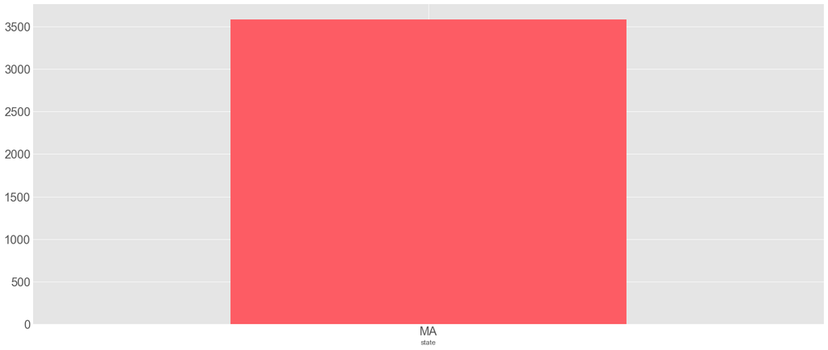

```python
lists_boston.state.value_counts(dropna=False).plot(kind='bar',color='#FD5C64',rot = 0,figsize=(24,10),fontsize=20)
plt.xlabel("state")
sns.despine()
```

AS we can see,all booking datas come from the state,Massachusetts.

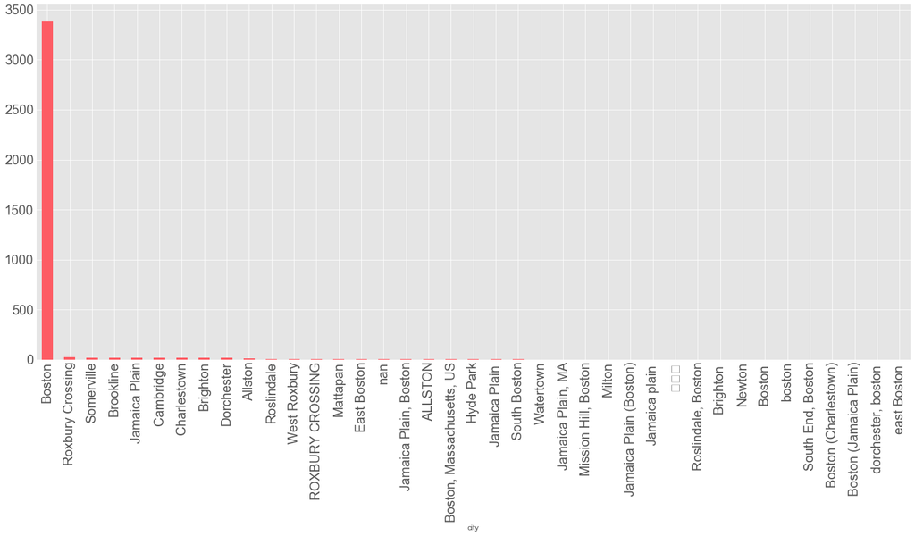

```python
lists_boston.city.value_counts(dropna=False).plot(kind='bar',color='#FD5C64',rot = 0,figsize=(24,10),fontsize=20)
plt.xlabel("city")
plt.xticks(rotation=90)
sns.despine()
```

AS we can see,most of booking datas come from the city,Boston,besides,some other cities include as well.

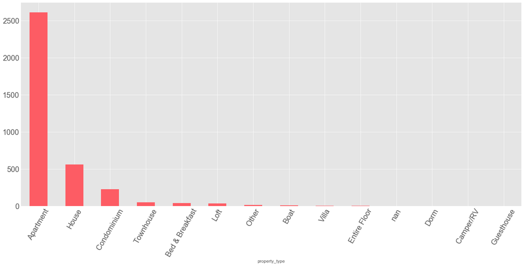

```python
lists_boston.property_type.value_counts(dropna=False).plot(kind='bar',color='#FD5C64',rot = 0,figsize=(24,10),fontsize=20)
plt.xlabel("property_type")
plt.xticks(rotation=60)
sns.despine()
```

From the picture above,I find mainly property types is "Apartment".

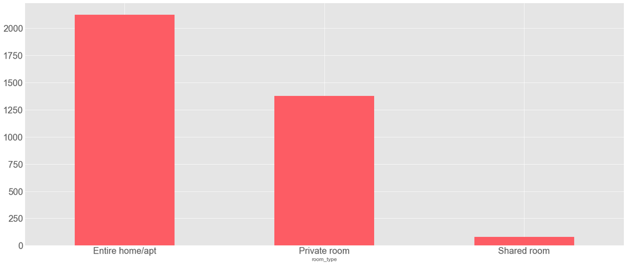

```python
lists_boston.room_type.value_counts(dropna=False).plot(kind='bar',color='#FD5C64',rot = 0,figsize=(24,10),fontsize=20)
plt.xlabel("room_type")
# plt.xticks(rotation=60)
sns.despine()
```

From the picture above,I find mainly room types are "Entire home" and "Private room".

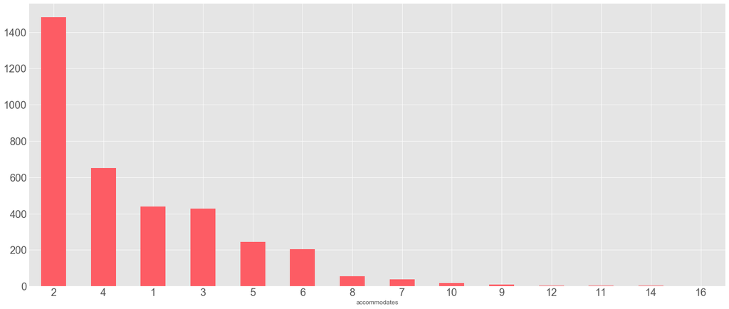

```python
lists_boston.accommodates.value_counts(dropna=False).plot(kind='bar',color='#FD5C64',rot = 0,figsize=(24,10),fontsize=20)
plt.xlabel("accommodates")
sns.despine()
```

As the picture above, I can see,most of accommodates are 1,2,4.

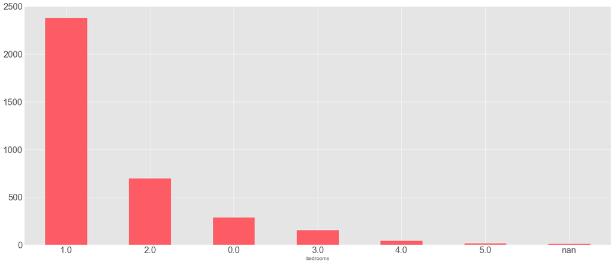

```python
lists_boston.bedrooms.value_counts(dropna=False).plot(kind='bar',color='#FD5C64',rot = 0,figsize=(24,10),fontsize=20)
plt.xlabel("bedrooms")
sns.despine()
```

As the picture above,I can see,most of bedrooms are 0,1,2.

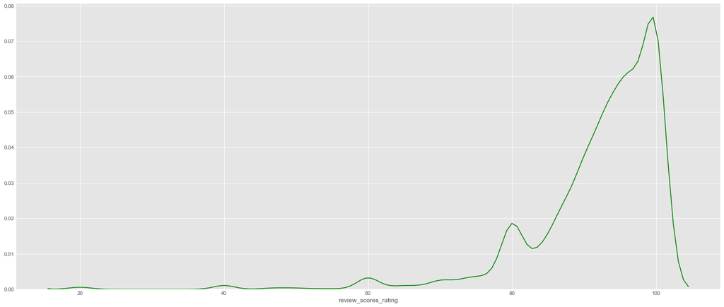

```python
sns.distplot(lists_boston.review_scores_rating.dropna(),hist=False,color="g")
plt.xlabel('review_scores_rating')
# plt.xlim([0,100])
sns.despine()
```

Most of review scores rating are more than 80.

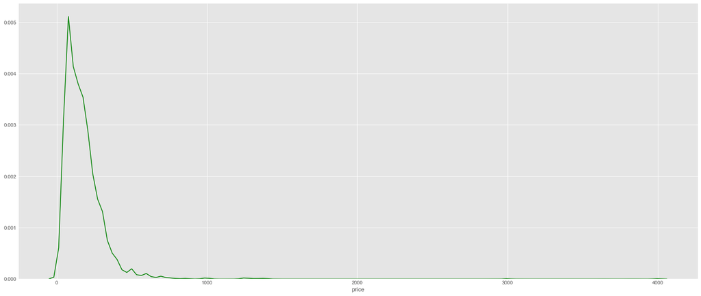

```python
lists_boston['price'] = lists_boston['price'].str.replace('$', '')
lists_boston['price'] = lists_boston['price'].str.replace(',', '').astype('float64')
sns.distplot(lists_boston.price.dropna(),hist=False,color="g")
plt.xlabel('price')
# plt.xlim([0,10])
sns.despine()
```

```python
%pylab
```

```
Using matplotlib backend: Qt5Agg
```

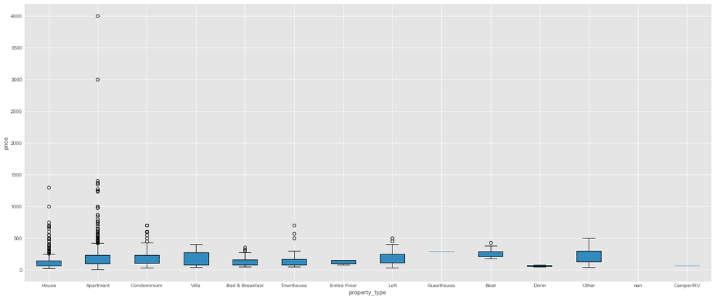

```python
lists_boston_price  = lists_boston[np.isfinite(lists_boston['price'])]
property_type = lists_boston_price.property_type.unique()
data_to_plot = []

## create the dataplot from the property_type dataframe
for property in property_type:
    data_to_plot.append(lists_boston[lists_boston.property_type == property].price)

## create a figure instance
fig = plt.figure(1,figsize(24,10))
# Create an axes instance
ax = fig.add_subplot(111)


# Create the boxplot
bp = ax.boxplot(data_to_plot,vert=True,patch_artist=True)

## Custom x-axis labels
ax.set_xticklabels(lists_boston.property_type.unique())


plt.xlabel("property_type")
plt.ylabel("price")
# plt.ylim([25,50])
plt.show()
```

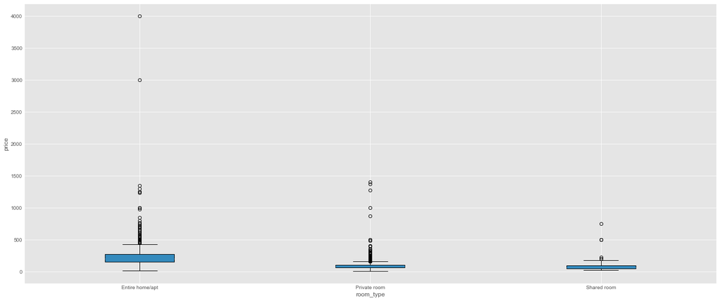

```python
lists_boston_price  = lists_boston[np.isfinite(lists_boston['price'])]
room_type = lists_boston_price.room_type.unique()
data_to_plot = []

## create the dataplot from the room_type dataframe
for room in room_type:
    data_to_plot.append(lists_boston[lists_boston.room_type == room].price)

## create a figure instance
fig = plt.figure(1,figsize(24,10))
# Create an axes instance
ax = fig.add_subplot(111)


# Create the boxplot
bp = ax.boxplot(data_to_plot,vert=True,patch_artist=True)

## Custom x-axis labels
ax.set_xticklabels(lists_boston.room_type.unique())


plt.xlabel("room_type")
plt.ylabel("price")
# plt.ylim([25,50])
plt.show()
```

The room type "Entire home" has higher price than other room types

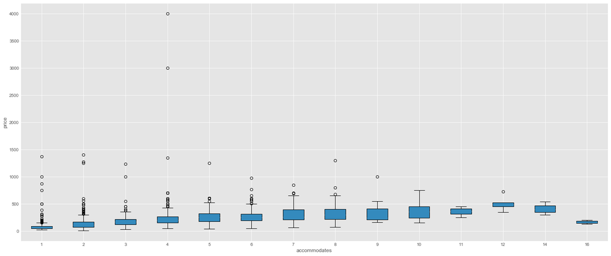

```python
lists_boston_price  = lists_boston[np.isfinite(lists_boston['price'])]
lists_boston_price['accommodates'] = lists_boston_price['accommodates'].astype('int')
accommodates = np.sort(lists_boston_price.accommodates.unique())
data_to_plot = []

## create the dataplot from the accommodates dataframe
for accommodate in accommodates:
    data_to_plot.append(lists_boston[lists_boston.accommodates == accommodate].price)

## create a figure instance
fig = plt.figure(1,figsize(24,10))
# Create an axes instance
ax = fig.add_subplot(111)


# Create the boxplot
bp = ax.boxplot(data_to_plot,vert=True,patch_artist=True)

## Custom x-axis labels
ax.set_xticklabels(np.sort(lists_boston.accommodates.unique()))


plt.xlabel("accommodates")
plt.ylabel("price")
# plt.ylim([25,50])
plt.show()
```

With the accommodates become bigger,the price becomes higher,when over 12,the price goes down.

Explore Data of reviews boston

```python
reviews_boston.head()
```

|  | listing_id | id | date | reviewer_id | reviewer_name | comments |
| --- | --- | --- | --- | --- | --- | --- |
| 0 | 1178162 | 4724140 | 2013-05-21 | 4298113 | Olivier | My stay at islam's place was really cool! Good... |
| 1 | 1178162 | 4869189 | 2013-05-29 | 6452964 | Charlotte | Great location for both airport and city - gre... |
| 2 | 1178162 | 5003196 | 2013-06-06 | 6449554 | Sebastian | We really enjoyed our stay at Islams house. Fr... |
| 3 | 1178162 | 5150351 | 2013-06-15 | 2215611 | Marine | The room was nice and clean and so were the co... |
| 4 | 1178162 | 5171140 | 2013-06-16 | 6848427 | Andrew | Great location. Just 5 mins walk from the Airp... |

```python
from wordcloud import WordCloud
import nltk
from nltk.corpus import stopwords
from nltk import sent_tokenize, word_tokenize
from wordcloud import WordCloud, STOPWORDS

# This founction is to plot the word cloud of comments
def wc(data,bgcolor,title):


    """Summary or Description of the Function

    Parameters:
    data (list): The list of split words
    bgcolor (str): The color of background

    Returns:
    image:Returning the picture of word cloud

   """
    plt.figure(figsize = (100,100))
    wc = WordCloud(background_color = bgcolor, max_words = 1000,  max_font_size = 50)
    wc.generate(' '.join(data))
    plt.imshow(wc)
    plt.axis('off')
```

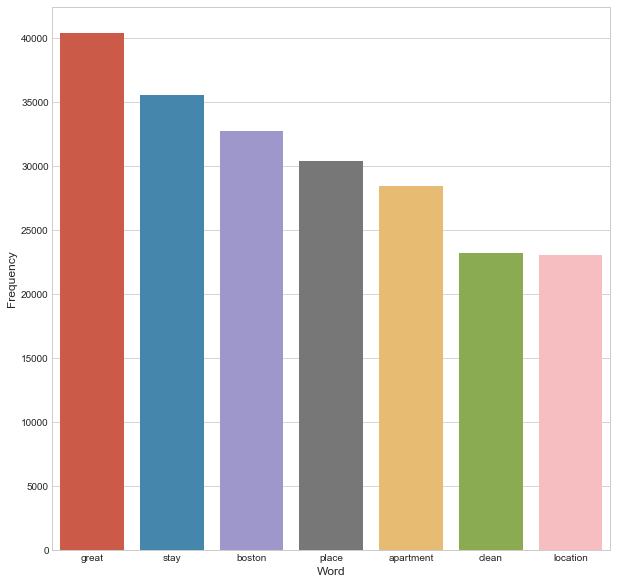

```python
from collections import Counter
from nltk.tokenize import RegexpTokenizer
from stop_words import get_stop_words
import re

top_N = 100
#convert list of list into text
#a=''.join(str(r) for v in df_usa['title'] for r in v)

a = reviews_boston['comments'].str.lower().str.cat(sep=' ')

# removes punctuation,numbers and returns list of words
b = re.sub('[^A-Za-z]+', ' ', a)

#remove all the stopwords from the text
stop_words = list(get_stop_words('en'))
nltk_words = list(stopwords.words('english'))
stop_words.extend(nltk_words)

word_tokens = word_tokenize(b)
filtered_sentence = [w for w in word_tokens if not w in stop_words]
filtered_sentence = []
for w in word_tokens:
    if w not in stop_words:
        filtered_sentence.append(w)

# Remove characters which have length less than 2
without_single_chr = [word for word in filtered_sentence if len(word) > 2]

# Remove numbers
cleaned_data_title = [word for word in without_single_chr if not word.isnumeric()]

# Calculate frequency distribution
word_dist = nltk.FreqDist(cleaned_data_title)
rslt = pd.DataFrame(word_dist.most_common(top_N),
                    columns=['Word', 'Frequency'])

plt.figure(figsize=(10,10))
sns.set_style("whitegrid")
ax = sns.barplot(x="Word",y="Frequency", data=rslt.head(7))
```

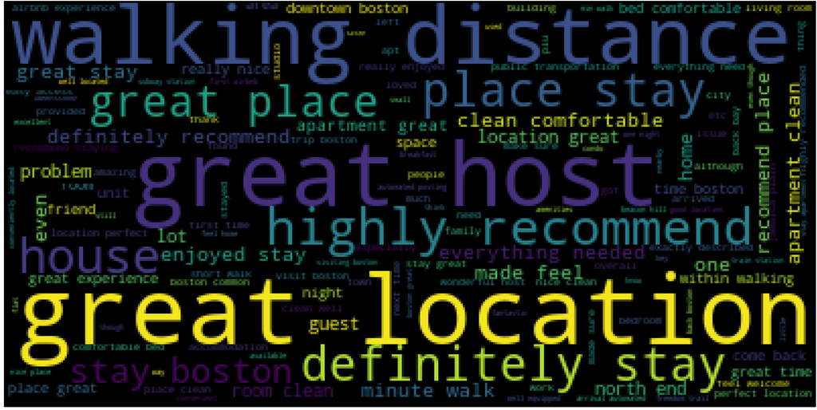

```python
wc(cleaned_data_title,'black','Common Words' )
```

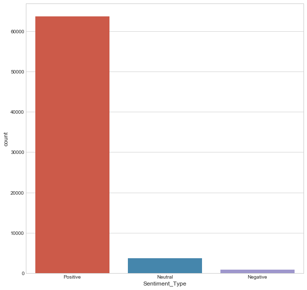

```python
from textblob import TextBlob

bloblist_desc = list()

reviews_boston_str=reviews_boston['comments'].astype(str)
for row in reviews_boston_str:
    blob = TextBlob(row)
    bloblist_desc.append((row,blob.sentiment.polarity, blob.sentiment.subjectivity))
    reviews_boston_polarity_desc = pd.DataFrame(bloblist_desc, columns = ['sentence','sentiment','polarity'])

def f(reviews_boston_polarity_desc):
    """
    This founction is to count all types of comments.

    Summary or Description of the Function

    Parameters:
    reviews_seattle_polarity_desc (DataFrame): The table includes each comments with  the sentiment and polarity.

    Returns:
    string:Returning the Sentiment type of each comment.


    """
    if reviews_boston_polarity_desc['sentiment'] > 0:
        val = "Positive"
    elif reviews_boston_polarity_desc['sentiment'] == 0:
        val = "Neutral"
    else:
        val = "Negative"
    return val

reviews_boston_polarity_desc['Sentiment_Type'] = reviews_boston_polarity_desc.apply(f, axis=1)

plt.figure(figsize=(10,10))
sns.set_style("whitegrid")
ax = sns.countplot(x="Sentiment_Type", data=reviews_boston_polarity_desc)
```

```python
# select the columns which maybe useful in the following analysis
lists_boston_data = lists_boston.loc[:,['name', 'summary', 'space', 'description',
    'host_response_time', 'host_response_rate', 'host_acceptance_rate', 'host_is_superhost',
     'property_type', 'room_type', 'latitude','longitude','square_feet','extra_people','weekly_price','monthly_price',
    'accommodates', 'bathrooms', 'bedrooms', 'beds', 'bed_type','is_location_exact',
    'amenities', 'price', 'cleaning_fee', 'minimum_nights',
    'maximum_nights', 'instant_bookable',
    'cancellation_policy', 'review_scores_rating', 'review_scores_accuracy',
    'review_scores_cleanliness', 'review_scores_checkin', 'review_scores_communication',
    'review_scores_location', 'review_scores_value']]
```

```python
#Get lengths of description elements
lists_boston_data.loc[:,'name_length'] = lists_boston_data['name'].str.len()
lists_boston_data.loc[:,'summary_length'] = lists_boston_data['summary'].str.len()
lists_boston_data.loc[:,'space_length'] = lists_boston_data['space'].str.len()
lists_boston_data.loc[:,'description_length'] = lists_boston_data['description'].str.len()
lists_boston_data.loc[:,'amenities_length'] = lists_boston_data['amenities'].str.len()
lists_boston_data.loc[:,'name_length'].fillna(0, inplace=True)
lists_boston_data.loc[:,'summary_length'].fillna(0, inplace=True)
lists_boston_data.loc[:,'space_length'].fillna(0, inplace=True)
lists_boston_data.loc[:,'description_length'].fillna(0, inplace=True)
lists_boston_data.loc[:,'amenities_length'] = lists_boston_data['amenities'].str.len()

#Drop original description variables
lists_boston_data = lists_boston_data.drop(['name', 'summary', 'space', 'description', 'amenities'], 1)
```

```python
#Recode host_response_time to integers as it is a spectrum
lists_boston_data['host_response_time'].replace('within an hour', 1, inplace=True)
lists_boston_data['host_response_time'].replace('within a few hours', 2, inplace=True)
lists_boston_data['host_response_time'].replace('within a day', 3, inplace=True)
lists_boston_data['host_response_time'].replace('a few days or more', 4, inplace=True)

#Impute missing values using mode
lists_boston_data['host_response_time'].fillna(lists_boston_data['host_response_time'].mode()[0], inplace=True)
```

```python
#Convert acceptance/response percentages to numbers
lists_boston_data['host_acceptance_rate'] = lists_boston_data['host_acceptance_rate'].replace('%','',regex=True).astype('float64')/100.00
lists_boston_data['host_response_rate'] = lists_boston_data['host_response_rate'].replace('%','',regex=True).astype('float64')/100.00

#Impute missing values using mean
lists_boston_data['host_response_rate'].fillna(lists_boston_data['host_response_rate'].mean(), inplace=True)
lists_boston_data['host_acceptance_rate'].fillna(lists_boston_data['host_acceptance_rate'].mean(), inplace=True)
```

```python
#Change f/t values to binary 0/1
lists_boston_data['host_is_superhost'].replace('t',1, inplace=True)
lists_boston_data['host_is_superhost'].replace('f',0, inplace=True)
lists_boston_data['instant_bookable'].replace('t',1, inplace=True)
lists_boston_data['instant_bookable'].replace('f',0, inplace=True)

lists_boston_data['is_location_exact'].replace('t',1, inplace=True)
lists_boston_data['is_location_exact'].replace('f',0, inplace=True)
```

```python
#Clean property_type category to 5 categories
def property_type_process(value):
    """
    This founction is to clean property_type category to 5 categories.

    Summary or Description of the Function

    Parameters:
    value (series): The column ‘property_type’ of ‘lists_boston_data’.

    Returns:
    string:Returning the new property type.


    """
    if value not in ['House', 'Apartment', 'Touwnhouse', 'Condominium']:
        return 'Other'
    return value

lists_boston_data['property_type'] = lists_boston_data['property_type'].apply(property_type_process)
```

```python
#Clean bed_type to binary real bed or other
def bed_type_process(value):
    if value not in ['Real Bed']:
        return 'Other'
    return value

lists_boston_data['bed_type'] = lists_boston_data['bed_type'].apply(bed_type_process)
```

```python
#Convert cleaning fee and price from strings to numbers
lists_boston_data['price'] = lists_boston_data['price'].str.replace('$', '')
lists_boston_data['price'] = lists_boston_data['price'].str.replace(',', '').astype('float64')

lists_boston_data['weekly_price'] = lists_boston_data['weekly_price'].str.replace('$', '')
lists_boston_data['weekly_price'] = lists_boston_data['weekly_price'].str.replace(',', '').astype('float64')

lists_boston_data['monthly_price'] = lists_boston_data['monthly_price'].str.replace('$', '')
lists_boston_data['monthly_price'] = lists_boston_data['monthly_price'].str.replace(',', '').astype('float64')

lists_boston_data['extra_people'] = lists_boston_data['extra_people'].str.replace('$', '')
lists_boston_data['extra_people'] = lists_boston_data['extra_people'].str.replace(',', '').astype('float64')

lists_boston_data['cleaning_fee'] = lists_boston_data['cleaning_fee'].str.replace('$', '')
lists_boston_data['cleaning_fee'] = lists_boston_data['cleaning_fee'].str.replace(',', '').astype('float64')
```

```python
#Missing data for cleaning fee indicates a $0 cleaning fee
lists_boston_data['cleaning_fee'].fillna(lists_boston_data['cleaning_fee'].mean(), inplace=True)

#Can't be sure what a missing value for these so we'll fill na
lists_boston_data['bathrooms'].fillna(lists_boston_data['bathrooms'].mode()[0], inplace=True)
lists_boston_data['bedrooms'].fillna(lists_boston_data['bedrooms'].mode()[0], inplace=True)
lists_boston_data['beds'].fillna(lists_boston_data['beds'].mode()[0], inplace=True)
lists_boston_data['host_is_superhost'].fillna(lists_boston_data['host_is_superhost'].mode()[0], inplace=True)

lists_boston_data['is_location_exact'].fillna(lists_boston_data['is_location_exact'].mode()[0], inplace=True)
```

```python
#Impute missing values using mean
lists_boston_data['review_scores_rating'].fillna(lists_boston_data['review_scores_rating'].mean(), inplace=True)
lists_boston_data['review_scores_accuracy'].fillna(lists_boston_data['review_scores_accuracy'].mean(), inplace=True)
lists_boston_data['review_scores_location'].fillna(lists_boston_data['review_scores_location'].mean(), inplace=True)
lists_boston_data['review_scores_value'].fillna(lists_boston_data['review_scores_value'].mean(), inplace=True)
lists_boston_data['review_scores_checkin'].fillna(lists_boston_data['review_scores_checkin'].mean(), inplace=True)
lists_boston_data['review_scores_communication'].fillna(lists_boston_data['review_scores_communication'].mean(), inplace=True)
lists_boston_data['review_scores_cleanliness'].fillna(lists_boston_data['review_scores_cleanliness'].mean(), inplace=True)
lists_boston_data['latitude'].fillna(lists_boston_data['latitude'].mean(), inplace=True)
lists_boston_data['longitude'].fillna(lists_boston_data['longitude'].mean(), inplace=True)
lists_boston_data['square_feet'].fillna(lists_boston_data['square_feet'].mean(), inplace=True)
lists_boston_data['extra_people'].fillna(lists_boston_data['extra_people'].mean(), inplace=True)
lists_boston_data['weekly_price'].fillna(lists_boston_data['weekly_price'].mean(), inplace=True)
lists_boston_data['monthly_price'].fillna(lists_boston_data['monthly_price'].mean(), inplace=True)
```

```python
lists_boston_data.info()
```

```
<class 'pandas.core.frame.DataFrame'>
RangeIndex: 3585 entries, 0 to 3584
Data columns (total 36 columns):
host_response_time             3585 non-null float64
host_response_rate             3585 non-null float64
host_acceptance_rate           3585 non-null float64
host_is_superhost              3585 non-null int64
property_type                  3585 non-null object
room_type                      3585 non-null object
latitude                       3585 non-null float64
longitude                      3585 non-null float64
square_feet                    3585 non-null float64
extra_people                   3585 non-null float64
weekly_price                   3585 non-null float64
monthly_price                  3585 non-null float64
accommodates                   3585 non-null int64
bathrooms                      3585 non-null float64
bedrooms                       3585 non-null float64
beds                           3585 non-null float64
bed_type                       3585 non-null object
is_location_exact              3585 non-null int64
price                          3585 non-null float64
cleaning_fee                   3585 non-null float64
minimum_nights                 3585 non-null int64
maximum_nights                 3585 non-null int64
instant_bookable               3585 non-null int64
cancellation_policy            3585 non-null object
review_scores_rating           3585 non-null float64
review_scores_accuracy         3585 non-null float64
review_scores_cleanliness      3585 non-null float64
review_scores_checkin          3585 non-null float64
review_scores_communication    3585 non-null float64
review_scores_location         3585 non-null float64
review_scores_value            3585 non-null float64
name_length                    3585 non-null int64
summary_length                 3585 non-null float64
space_length                   3585 non-null float64
description_length             3585 non-null int64
amenities_length               3585 non-null int64
dtypes: float64(23), int64(9), object(4)
memory usage: 1008.4+ KB
```

```
price                          1.000000
accommodates                   0.437756
bedrooms                       0.384895
beds                           0.370671
monthly_price                  0.351652
weekly_price                   0.343240
cleaning_fee                   0.328903
bathrooms                      0.248554
latitude                       0.196270
space_length                   0.168882
longitude                      0.165621
review_scores_location         0.129765
amenities_length               0.106389
review_scores_cleanliness      0.098087
description_length             0.073479
review_scores_rating           0.070753
is_location_exact              0.066388
square_feet                    0.049213
extra_people                   0.028703
review_scores_accuracy         0.027566
name_length                    0.020127
minimum_nights                 0.020054
review_scores_value            0.007918
host_is_superhost              0.006054
review_scores_communication    0.002419
host_response_time            -0.002499
review_scores_checkin         -0.002577
maximum_nights                -0.005498
host_response_rate            -0.005680
summary_length                -0.018901
instant_bookable              -0.057359
host_acceptance_rate          -0.115013
Name: price, dtype: float64
```

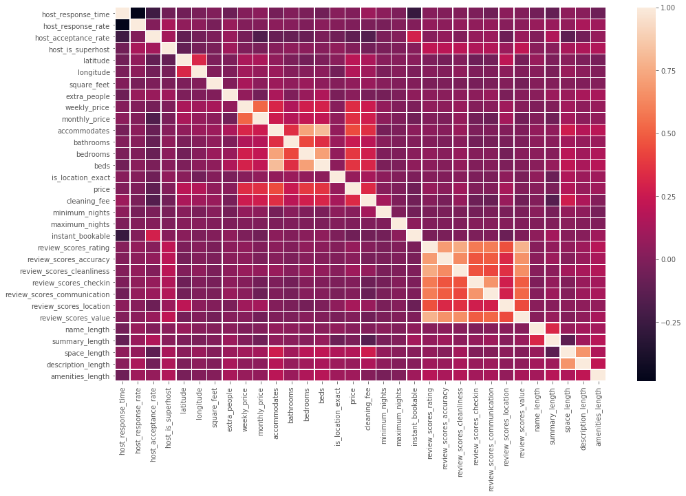

```python
#Correlation Matrix
import matplotlib.pyplot as plt
import seaborn as sns
plt.style.use('ggplot')
fig, ax = plt.subplots(figsize=(16,10))
corr = lists_boston_data.corr()
corr = (corr)
sns.heatmap(corr,
            xticklabels=corr.columns.values,
            yticklabels=corr.columns.values, linewidths=.5, ax=ax)
corr['price'].sort_values(ascending=False)
```

```python
lists_boston_data.head()
```

|  | host_response_time | host_response_rate | host_acceptance_rate | host_is_superhost | property_type | room_type | latitude | longitude | square_feet | extra_people | ... | review_scores_cleanliness | review_scores_checkin | review_scores_communication | review_scores_location | review_scores_value | name_length | summary_length | space_length | description_length | amenities_length |
| --- | --- | --- | --- | --- | --- | --- | --- | --- | --- | --- | --- | --- | --- | --- | --- | --- | --- | --- | --- | --- | --- |
| 0 | 1.0 | 0.949891 | 0.841731 | 0 | House | Entire home/apt | 42.282619 | -71.133068 | 858.464286 | 0.0 | ... | 9.258041 | 9.646293 | 9.646549 | 9.414043 | 9.168234 | 26 | 249.0 | 481.0 | 1000 | 222 |
| 1 | 1.0 | 1.000000 | 1.000000 | 0 | Apartment | Private room | 42.286241 | -71.134374 | 858.464286 | 0.0 | ... | 9.000000 | 10.000000 | 10.000000 | 9.000000 | 9.000000 | 33 | 247.0 | 73.0 | 1000 | 286 |
| 2 | 2.0 | 1.000000 | 0.880000 | 1 | Apartment | Private room | 42.292438 | -71.135765 | 858.464286 | 20.0 | ... | 9.000000 | 10.000000 | 10.000000 | 9.000000 | 10.000000 | 32 | 244.0 | 1000.0 | 1000 | 316 |
| 3 | 2.0 | 1.000000 | 0.500000 | 0 | House | Private room | 42.281106 | -71.121021 | 858.464286 | 25.0 | ... | 10.000000 | 10.000000 | 10.000000 | 10.000000 | 10.000000 | 45 | 493.0 | 631.0 | 1000 | 308 |
| 4 | 1.0 | 1.000000 | 1.000000 | 1 | House | Private room | 42.284512 | -71.136258 | 858.464286 | 0.0 | ... | 10.000000 | 10.000000 | 10.000000 | 9.000000 | 10.000000 | 19 | 245.0 | 248.0 | 1000 | 180 |

5 rows × 36 columns

```python
# checking missing data
total = lists_boston_data.isnull().sum().sort_values(ascending = False)
percent = (lists_boston_data.isnull().sum()/lists_boston_data.isnull().count()*100).sort_values(ascending = False)
missing_data  = pd.concat([total, percent], axis=1, keys=['Total', 'Percent'])
missing_data.head(20)
```

|  | Total | Percent |
| --- | --- | --- |
| amenities_length | 0 | 0.0 |
| description_length | 0 | 0.0 |
| beds | 0 | 0.0 |
| bedrooms | 0 | 0.0 |
| bathrooms | 0 | 0.0 |
| accommodates | 0 | 0.0 |
| monthly_price | 0 | 0.0 |
| weekly_price | 0 | 0.0 |
| extra_people | 0 | 0.0 |
| square_feet | 0 | 0.0 |
| longitude | 0 | 0.0 |
| latitude | 0 | 0.0 |
| room_type | 0 | 0.0 |
| property_type | 0 | 0.0 |
| host_is_superhost | 0 | 0.0 |
| host_acceptance_rate | 0 | 0.0 |
| host_response_rate | 0 | 0.0 |
| bed_type | 0 | 0.0 |
| is_location_exact | 0 | 0.0 |
| price | 0 | 0.0 |

```python
def clean_data(df):

    """
    This founction is to do further data cleaning and Dummy the categorical variables.

    Summary or Description of the Function

    Parameters:
    df (dataframe): The table of ‘lists_seattle_data’.

    Returns:
    X(dataframe)：Returning the new table without the columns 'price' and other columns.
    y(series)：Returning the column 'price'.


    """


    # Drop rows with missing salary values
    df = df.dropna(subset=['price'], axis=0)
    y = df['price']

    #Drop respondent and expected salary columns
#     df = df.drop(['review_scores_value','review_scores_cleanliness','review_scores_accuracy','review_scores_communication',
#                   'review_scores_checkin','review_scores_location','bedrooms','beds','space_length'], axis=1)


    # Dummy the categorical variables
    cat_vars = df.select_dtypes(include=['object']).copy().columns
    for var in  cat_vars:
        # for each cat add dummy var, drop original column
        df = pd.concat([df.drop(var, axis=1), pd.get_dummies(df[var], prefix=var, prefix_sep='_', drop_first=True)], axis=1)

    df=df.drop(['price'], axis=1)
    X = df
    return X, y

#Use the function to create X and y
X, y = clean_data(lists_boston_data)
```

```python
X.head()
```

|  | host_response_time | host_response_rate | host_acceptance_rate | host_is_superhost | latitude | longitude | square_feet | extra_people | weekly_price | monthly_price | ... | amenities_length | property_type_Condominium | property_type_House | property_type_Other | room_type_Private room | room_type_Shared room | bed_type_Real Bed | cancellation_policy_moderate | cancellation_policy_strict | cancellation_policy_super_strict_30 |
| --- | --- | --- | --- | --- | --- | --- | --- | --- | --- | --- | --- | --- | --- | --- | --- | --- | --- | --- | --- | --- | --- |
| 0 | 1.0 | 0.949891 | 0.841731 | 0 | 42.282619 | -71.133068 | 858.464286 | 0.0 | 922.392377 | 3692.097973 | ... | 222 | 0 | 1 | 0 | 0 | 0 | 1 | 1 | 0 | 0 |
| 1 | 1.0 | 1.000000 | 1.000000 | 0 | 42.286241 | -71.134374 | 858.464286 | 0.0 | 400.000000 | 3692.097973 | ... | 286 | 0 | 0 | 0 | 1 | 0 | 1 | 1 | 0 | 0 |
| 2 | 2.0 | 1.000000 | 0.880000 | 1 | 42.292438 | -71.135765 | 858.464286 | 20.0 | 395.000000 | 1350.000000 | ... | 316 | 0 | 0 | 0 | 1 | 0 | 1 | 1 | 0 | 0 |
| 3 | 2.0 | 1.000000 | 0.500000 | 0 | 42.281106 | -71.121021 | 858.464286 | 25.0 | 922.392377 | 3692.097973 | ... | 308 | 0 | 1 | 0 | 1 | 0 | 1 | 1 | 0 | 0 |
| 4 | 1.0 | 1.000000 | 1.000000 | 1 | 42.284512 | -71.136258 | 858.464286 | 0.0 | 922.392377 | 3692.097973 | ... | 180 | 0 | 1 | 0 | 1 | 0 | 1 | 0 | 0 | 0 |

5 rows × 40 columns